# DAPR2 10 – RQ2 step by step

```r
# # load libraries
library(tidyverse)  # for all things!
# library(psych)      # good for descriptive stats
# library(kableExtra) # useful for creating nice tables
# library(sjPlot)     # regression tables & plots
# library(emmeans)    # for contrasts
# library(car)        # for assumptions (crPlots, residualPlots, VIF) and bootstrapping

data1 <- read_csv("https://uoepsy.github.io/data/DapR2_S1B2_PracticalPart1.csv")
```

RQ2: Is there a difference in attendance between those with early/late classes in comparison to those with midday classes?

# (1) Before model fitting

## Identify the relevant variables

```r
data1 |> head()
```

| pid | Attendance | Conscientiousness | Time | OnlineAccess | Year |
| --- | --- | --- | --- | --- | --- |
| 1 | 9 | High | 3PM | Often | Y3 |
| 2 | 10 | High | 2PM | Often | Y3 |
| 3 | 0 | Low | 10AM | Rarely | Y2 |
| 4 | 8 | Low | 4PM | Often | Y4 |
| 5 | 6 | High | 4PM | Sometimes | Y1 |
| 6 | 6 | High | 9AM | Sometimes | Y1 |

RQ2: Is there a difference in attendance between those with early/late classes in comparison to those with midday classes?

- `Time`
- `Attendance`

## Data tidying (e.g., missingness? factor levels?)

Missingness:

```r
is.na(data1) |> table()
```

```
FALSE
 2382
```

Factor levels:

```r
unique(data1$Time)
```

```
[1] "3PM"  "2PM"  "10AM" "4PM"  "9AM"  "11AM" "1PM"  "12PM"
```

```r
data1 <- data1 |>
  mutate(
    Time = factor(Time, levels = c('9AM', '10AM', '11AM', '12PM', '1PM', '2PM', '3PM', '4PM'))
  )
```

## Get summary statistics for the relevant variables

```r
data1$Time |> table()
```

```
 9AM 10AM 11AM 12PM  1PM  2PM  3PM  4PM
  56   48   46   47   45   46   52   57
```

Mode: 4PM

```r
psych::describe(data1$Attendance)
```

|  | vars | n | mean | sd | median | trimmed | mad | min | max | range | skew | kurtosis | se |
| --- | --- | --- | --- | --- | --- | --- | --- | --- | --- | --- | --- | --- | --- |
| X1 | 1 | 397 | 28.28 | 13.99 | 29 | 28.31 | 16.31 | 0 | 60 | 60 | -0.03 | -1 | 0.7 |

## Plot each relevant variable individually

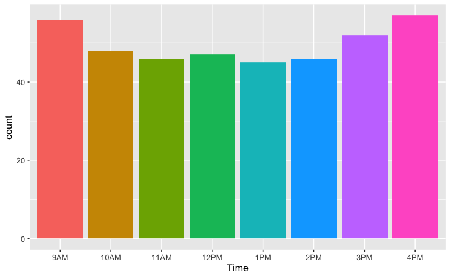

```r
data1 |>
  ggplot(aes(x = Time, fill = Time)) +
  geom_bar() +
  theme(legend.position = 'none')
```

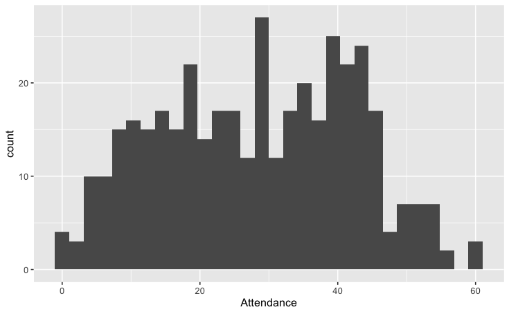

```r
data1 |>
  ggplot(aes(x = Attendance)) +
  geom_histogram()
```

## Plot the relevant variables together

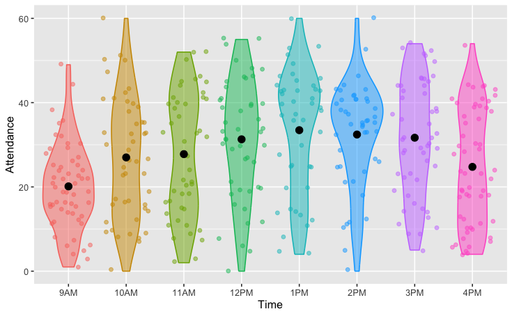

```r
data1 |>
  ggplot(aes(x = Time, y = Attendance, fill = Time, colour = Time)) +
  geom_violin(alpha = 0.5) +
  geom_jitter(alpha = 0.5) +
  stat_summary(geom = 'point', fun = 'mean', colour = 'black', size = 3) +
  theme(legend.position = 'none')
```

Our rsch q is about early/late versus midday.

- Early/late = 9AM, 10AM, 3PM, 4PM.
- Midday = 11AM, 12PM, 1PM, 2PM.

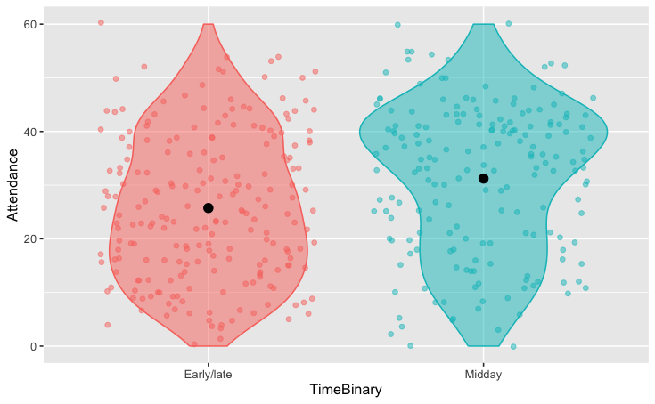

```r
data1 |>
  mutate(
    TimeBinary = ifelse(
      Time %in% c('9AM', '10AM', '3PM', '4PM'),
      'Early/late',
      'Midday'
    )
  ) |>
  ggplot(aes(x = TimeBinary, y = Attendance, fill = TimeBinary, colour = TimeBinary)) +
  geom_violin(alpha = 0.5) +
  geom_jitter(alpha = 0.5) +
  stat_summary(geom = 'point', fun = 'mean', colour = 'black', size = 3) +
  theme(legend.position = 'none')
```

## Set up categorical predictors (e.g., what a priori coding scheme?)

```r
contrasts(data1$Time)
```

```
     10AM 11AM 12PM 1PM 2PM 3PM 4PM
9AM     0    0    0   0   0   0   0
10AM    1    0    0   0   0   0   0
11AM    0    1    0   0   0   0   0
12PM    0    0    1   0   0   0   0
1PM     0    0    0   1   0   0   0
2PM     0    0    0   0   1   0   0
3PM     0    0    0   0   0   1   0
4PM     0    0    0   0   0   0   1
```

## Set up continuous predictors (e.g., any transformations?)

NA

## Think what the model coefficients might look like

- all positive (but not that interesting)

## Formally state null and alternative hypotheses

H0 in words: - The mean of early/late classes is equal to the mean of the midday classes.

$$H0 : \mu_{\text{early/late}} = \mu_{\text{midday}}$$

So:

$$\begin{align}
H0 &: (\mu_{\text{9AM}} + \mu_{\text{10AM}} + \mu_{\text{3PM}} +
\mu_{\text{4PM}})/4 = (\mu_{\text{11AM}} + \mu_{\text{12PM}} +
\mu_{\text{1PM}} + \mu_{\text{2PM}})/4 \\
H0 &: \frac{1}{4} (\mu_{\text{9AM}} + \mu_{\text{10AM}} +
\mu_{\text{3PM}} + \mu_{\text{4PM}}) = \frac{1}{4} (\mu_{\text{11AM}} +
\mu_{\text{12PM}} + \mu_{\text{1PM}} + \mu_{\text{2PM}})
\end{align}$$

Then H1:

$$H1 : \frac{1}{4} (\mu_{\text{9AM}} + \mu_{\text{10AM}} +
\mu_{\text{3PM}} + \mu_{\text{4PM}}) \neq \frac{1}{4} (\mu_{\text{11AM}}
+ \mu_{\text{12PM}} + \mu_{\text{1PM}} + \mu_{\text{2PM}})$$

# (2) Model fitting

## Fit the linear model to the data

```r
m2 <- lm(Attendance ~ Time, data = data1)
```

# (3) After model fitting

## Check model assumptions

Linearity: Assumed bc categorical.

Independence of errors: Assumed bc between subjects.

Normality of errors:

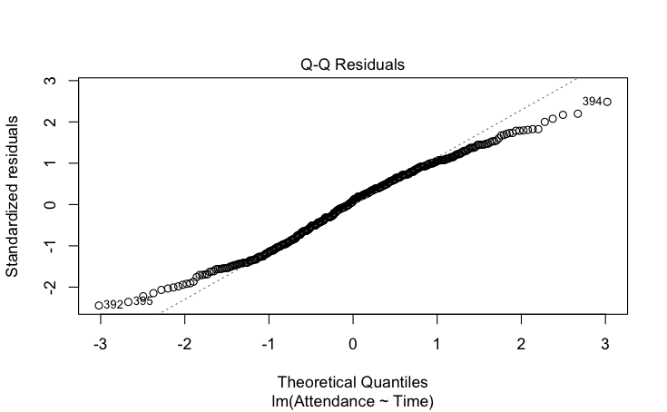

```r
plot(m2, which = 2)
```

Some deviations around the edges … meh.

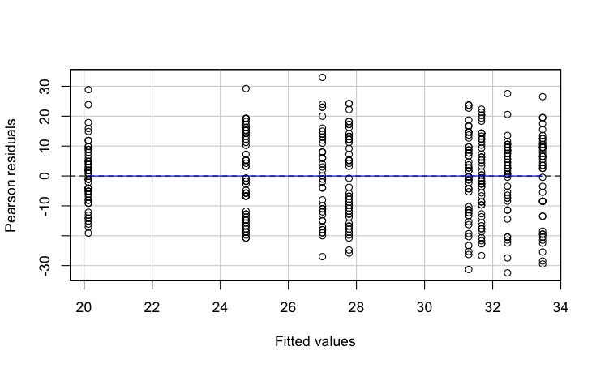

```r
car::residualPlot(m2)
```

There are so few diff values because these are the fitted values = the means for each time.

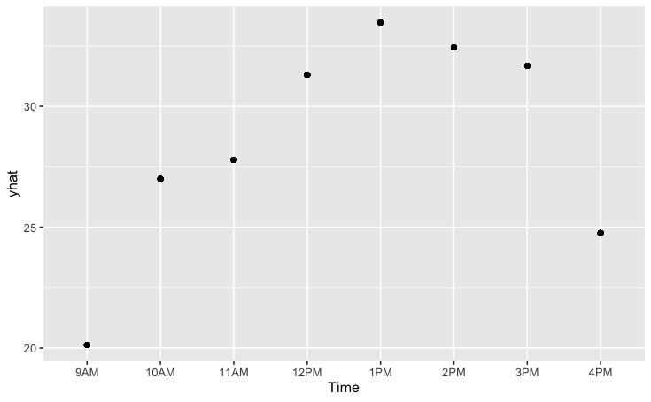

```r
m2$model |>
  mutate(
    yhat = fitted(m2)
  ) |>
  ggplot(aes(x = Time, y = yhat)) +
  geom_point()
```

```r
NA
```

Looks fine.

## Bootstrap the linear model

NA.

## Run diagnostics for multicollinearity

NA

## Interpret the model coefficients

```r
summary(m2)
```

```
Call:
lm(formula = Attendance ~ Time, data = data1)

Residuals:
    Min      1Q  Median      3Q     Max
-32.435 -10.298   1.327  10.246  33.000

Coefficients:
            Estimate Std. Error t value Pr(>|t|)
(Intercept)   20.125      1.793  11.226  < 2e-16 ***
Time10AM       6.875      2.639   2.605  0.00953 **
Time11AM       7.658      2.669   2.869  0.00435 **
Time12PM      11.173      2.654   4.210 3.17e-05 ***
Time1PM       13.342      2.686   4.968 1.02e-06 ***
Time2PM       12.310      2.669   4.611 5.43e-06 ***
Time3PM       11.548      2.583   4.470 1.03e-05 ***
Time4PM        4.629      2.524   1.834  0.06740 .
---
Signif. codes:  0 ‘***’ 0.001 ‘**’ 0.01 ‘*’ 0.05 ‘.’ 0.1 ‘ ’ 1

Residual standard error: 13.41 on 389 degrees of freedom
Multiple R-squared:  0.0974,    Adjusted R-squared:  0.08116
F-statistic: 5.997 on 7 and 389 DF,  p-value: 1.196e-06
```

as expected.

## Run sensitivity analysis

NA.

## Get estimated marginal means

```r
m2_emm <- emmeans::emmeans(m2, ~Time)
m2_emm
```

```
 Time emmean   SE  df lower.CL upper.CL
 9AM    20.1 1.79 389     16.6     23.6
 10AM   27.0 1.94 389     23.2     30.8
 11AM   27.8 1.98 389     23.9     31.7
 12PM   31.3 1.96 389     27.5     35.1
 1PM    33.5 2.00 389     29.5     37.4
 2PM    32.4 1.98 389     28.5     36.3
 3PM    31.7 1.86 389     28.0     35.3
 4PM    24.8 1.78 389     21.3     28.2

Confidence level used: 0.95
```

## Plot estimated marginal means

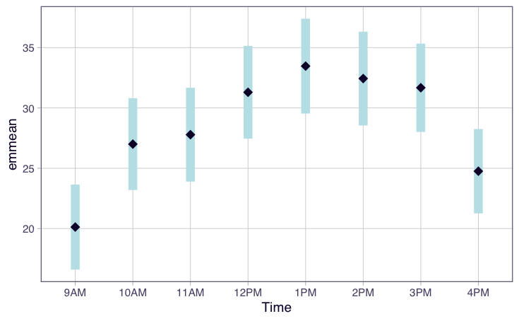

```r
plot(m2_emm) + coord_flip()
```

## Create and test manual contrasts

```r
levels(data1$Time)
```

```
[1] "9AM"  "10AM" "11AM" "12PM" "1PM"  "2PM"  "3PM"  "4PM"
```

Four in each chunk, so the weights will be –1/4 and +1/4.

```r
m2_comparison <- list(
  'earlylate vs. midday' = c(1/4, 1/4,  -1/4, -1/4, -1/4, -1/4, 1/4, 1/4)
)

(m2_contrast <- emmeans::contrast(m2_emm, m2_comparison))
```

```
 contrast             estimate   SE  df t.ratio p.value
 earlylate vs. midday    -5.36 1.35 389  -3.963  0.0001
```

```r
confint(m2_contrast)
```

```
 contrast             estimate   SE  df lower.CL upper.CL
 earlylate vs. midday    -5.36 1.35 389    -8.01     -2.7

Confidence level used: 0.95
```

## Write up your analysis

[in lab]